# distance between players

Rename data frame to match data.

```r
merged.games.plays.tracking.all <- mergedgamesplaystrackingall
```

Delete unnecessary columns.

```r
merged.games.plays.tracking.all <- subset(mergedgamesplaystrackingall, select = - c(kickBlockerId, snapDetail, passResult))
```

Duplicate merged data frame.

```r
merged.games.plays.tracking.all2 <- merged.games.plays.tracking.all
```

Merge tracking data with itself using left join.

```r
merged.all.distance <- left_join(
  merged.games.plays.tracking.all,
  merged.games.plays.tracking.all2,
  by = c("gameId", "gameDate", "gameTimeEastern", "gameClock", "homeTeamAbbr", "visitorTeamAbbr", "time", "event", "frameId", "playId", "playDirection", "season", "week", "playDescription", "down", "quarter", "yardsToGo", "possessionTeam", "specialTeamsPlayType", "specialTeamsResult", "kickerId", "returnerId", "yardlineSide", "yardlineNumber", "penaltyCodes", "penaltyJerseyNumbers", "penaltyYards", "preSnapHomeScore", "preSnapVisitorScore", "kickLength", "kickReturnYardage", "playResult", "absoluteYardlineNumber", "snapTime", "operationTime", "hangTime", "kickType", "kickDirectionIntended", "kickDirectionActual", "returnDirectionIntended", "returnDirectionActual", "missedTackler", "assistTackler", "tackler", "kickoffReturnFormation", "gunners", "puntRushers", "specialTeamsSafeties", "vises", "kickContactType"),
  copy = FALSE,
  suffix = c(".1", ".2"),
  keep = FALSE
)
```

Define teams as “kicking” and “receiving”.

```r
merged.all.distance <- mutate(merged.all.distance, playTeam.1 = ifelse(homeTeamAbbr == possessionTeam & team.1 == "home", "kicking", ""))
merged.all.distance <- mutate(merged.all.distance, playTeam.1 = ifelse(visitorTeamAbbr == possessionTeam & team.1 == "home", "receiving", playTeam.1))
merged.all.distance <- mutate(merged.all.distance, playTeam.1 = ifelse(homeTeamAbbr == possessionTeam & team.1 == "away", "receiving", playTeam.1))
merged.all.distance <- mutate(merged.all.distance, playTeam.1 = ifelse(visitorTeamAbbr == possessionTeam & team.1 == "away", "kicking", playTeam.1))
merged.all.distance <- mutate(merged.all.distance, playTeam.2 = ifelse(homeTeamAbbr == possessionTeam & team.2 == "home", "kicking", ""))
merged.all.distance <- mutate(merged.all.distance, playTeam.2 = ifelse(visitorTeamAbbr == possessionTeam & team.2 == "home", "receiving", playTeam.2))
merged.all.distance <- mutate(merged.all.distance, playTeam.2 = ifelse(homeTeamAbbr == possessionTeam & team.2 == "away", "receiving", playTeam.2))
merged.all.distance <- mutate(merged.all.distance, playTeam.2 = ifelse(visitorTeamAbbr == possessionTeam & team.2 == "away", "kicking", playTeam.2))
merged.all.distance <- mutate(merged.all.distance, playTeam.1 = ifelse(team.1 == "football", "football", playTeam.1))
merged.all.distance <- mutate(merged.all.distance, playTeam.2 = ifelse(team.2 == "football", "football", playTeam.2))
```

Create variable to calculate distance.

```r
merged.all.distance$xDiff <- merged.all.distance$x.1 - merged.all.distance$x.2
merged.all.distance$yDiff <- merged.all.distance$y.1 - merged.all.distance$y.2
merged.all.distance$playerDistanceSquared <- merged.all.distance$xDiff^2 + merged.all.distance$yDiff^2
merged.all.distance$playerDistance <- sqrt(merged.all.distance$playerDistanceSquared)
merged.all.distance <- subset(merged.all.distance, select = -c(xDiff,yDiff,playerDistanceSquared) )
```

Flag distances of less than 5 yards.

```r
merged.all.distance <- mutate(merged.all.distance, lessThan5 = ifelse(playerDistance<=5, "Y", "N"))
```

Filter out distances between the same players.

```r
merged.all.distance <- filter(merged.all.distance, displayName.1 != displayName.2)
```

```r
unique(merged.all.distance$playTeam.1)
```

```
[1] "kicking"   "receiving" "football"
```

```r
unique(merged.all.distance$playTeam.2)
```

```
[1] "receiving" "kicking"   "football"
```

Filter receiving team members that are within one yard of the football to identify returner/ball receiver.

```r
merged.all.distance.receivertofootball <- filter(merged.all.distance, playTeam.1 == "receiving" & playTeam.2 == "football" & playerDistance < 1)
```

Flag the returner/ball receiver whenever he is player 1.

```r
merged.all.distance.receivertofootball <- mutate(merged.all.distance.receivertofootball, receiver = ifelse(nflId.1 == returnerId | playTeam.1 == "receiving" & playTeam.2 == "football" & playerDistance < 1, "Y", ""))
```

Delete unnecessary columns from returner/ball receiver data frame.

```r
merged.all.distance.receivertofootball <- subset(merged.all.distance.receivertofootball, select = c("gameId", "frameId", "playId", "nflId.1", "displayName.1", "receiver", "playDescription"))
```

Concatenate game ID and play ID to create unique play ID.

```r
merged.all.distance.receivertofootball <- mutate(merged.all.distance.receivertofootball, uniquePlayId = paste(gameId, playId, sep = "-"))
```

Concatenate unique play ID and NFL ID.

```r
merged.all.distance.receivertofootball <- mutate(merged.all.distance.receivertofootball, PlayId.receiver = paste(uniquePlayId, nflId.1, sep = "-"))
```

Determine whether any plays have multiple designated receivers.

```r
n_occur <- data.frame(table(merged.all.distance.receivertofootball$uniquePlayId))
```

Filter n_occur to find plays with more than 1 designated receiver.

```r
n_occur <- filter(n_occur, Freq > 1)
```

Choose the plays with more than 1 designated receiver, identify the correct receiver, filter out incorrect receivers.

```r
merged.all.distance.receivertofootball.duplicates <- filter(merged.all.distance.receivertofootball, uniquePlayId %in% n_occur$Var1)
```

Delete correct receivers in order to have set to filter out.

```r
merged.all.distance.receivertofootball.duplicates <- merged.all.distance.receivertofootball.duplicates %>% slice(-c(2, 4, 6, 7, 9, 12, 13, 15, 17, 21, 22, 25, 26, 28, 30, 33, 36, 37, 39, 42))
```

Filter out duplicates.

```r
merged.all.distance.receivertofootball <- filter(merged.all.distance.receivertofootball, !PlayId.receiver %in% merged.all.distance.receivertofootball.duplicates$PlayId.receiver)
```

Merge receiver data into original data frame.

```r
merged.all.distance.final <- left_join(
  merged.all.distance,
  merged.all.distance.receivertofootball,
  by = c("gameId", "frameId", "playId", "nflId.1", "displayName.1", "playDescription"),
  copy = FALSE,
  suffix = c(".1", ".2"),
  keep = FALSE
)
```

Filter by receiver.

```r
merged.all.distance.final <- filter(merged.all.distance.final, receiver == "Y")
```

Remove unnecessary columns.

```r
merged.all.distance.final <- subset(merged.all.distance.final, select = -c(snapTime, operationTime, event, specialTeamsPlayType, down, yardsToGo,  PlayId.receiver))
```

Filter out distance between receiver and football.

```r
merged.all.distance.final <- filter(merged.all.distance.final, displayName.2 != "football")
```

Group distance data by game ID, play ID, kicking or receiving team, whether player is within 5 yards of receiver.

```r
merged.all.distance.final %>% count(playTeam.2, lessThan5, gameId, playId)
```

| playTeam.2 | lessThan5 | gameId | playId | n |
| --- | --- | --- | --- | --- |
| kicking | N | 2018090600 | 677 | 11 |
| kicking | N | 2018090600 | 1606 | 11 |
| kicking | N | 2018090900 | 1992 | 11 |
| kicking | N | 2018090900 | 2777 | 11 |
| kicking | N | 2018090900 | 2915 | 11 |
| kicking | N | 2018090900 | 4236 | 11 |
| kicking | N | 2018090901 | 2022 | 11 |
| kicking | N | 2018090901 | 2489 | 11 |
| kicking | N | 2018090901 | 3815 | 11 |
| kicking | N | 2018090902 | 36 | 11 |

[output cut: 990 more lines]

Filter by number of players within 5 yards of receiver.

```r
merged.all.distance.lessThan5 <- filter(merged.all.distance.final, lessThan5 == "Y")
```

Group distance data by game ID, play ID, kicking or receiving team.

```r
n_players_nearby <- merged.all.distance.lessThan5 %>% count(playTeam.2, gameId, playId)
```

Create data frames for kicking team players nearby and receiving team players nearby.

```r
kicking_players_nearby <- filter(n_players_nearby, playTeam.2 == "kicking")
receiving_players_nearby <- filter(n_players_nearby, playTeam.2 == "receiving")
```

Rename columns.

```r
kicking_players_nearby <- kicking_players_nearby %>%
  rename(kickTeamWithin5 = "n")
receiving_players_nearby <- receiving_players_nearby %>%
  rename(receivingTeamWithin5 = "n")
```

Drop unnecessary columns.

```r
kicking_players_nearby <- subset(kicking_players_nearby, select = -c(playTeam.2))
receiving_players_nearby <- subset(receiving_players_nearby, select = -c(playTeam.2))
```

Merge kicking and receiving players nearby with main data frame.

```r
merged.all.distance.final <- left_join(
  merged.all.distance.final,
  kicking_players_nearby,
  by = c("gameId", "playId"),
  copy = FALSE,
  suffix = c(".1", ".2"),
  keep = FALSE
)

merged.all.distance.final <- left_join(
  merged.all.distance.final,
  receiving_players_nearby,
  by = c("gameId", "playId"),
  copy = FALSE,
  suffix = c(".1", ".2"),
  keep = FALSE
)
```

Replace NAs in receiving_players_nearby and kicking_players_nearby with 0.

```r
merged.all.distance.final$kickTeamWithin5[is.na(merged.all.distance.final$kickTeamWithin5)] <- 0
merged.all.distance.final$receivingTeamWithin5[is.na(merged.all.distance.final$receivingTeamWithin5)] <- 0
```

Blockers = players on receiving team Coverage = players on kicking team

We assume that returners would be more likely to attempt a return and to achieve more of a return if there are more blockers near the receiver than coverage team members. Thus find difference between the two columns.

```r
merged.all.distance.final$netCoverage <- merged.all.distance.final$kickTeamWithin5 - merged.all.distance.final$receivingTeamWithin5
```

Next, find the distance between the receiver and the closest member of the kicking team to determine how much running room the returner has.

```r
merged.all.distance.final.kicking <- filter(merged.all.distance.final, playTeam.2 == "kicking")
merged.all.distance.final.kicking <- group_by(merged.all.distance.final.kicking, uniquePlayId)
merged.all.distance.final.closestcoverage <- filter(merged.all.distance.final.kicking, rank(playerDistance, ties.method="first")==1)
```

Rename and drop columns.

```r
merged.all.distance.final.closestcoverage <- merged.all.distance.final.closestcoverage %>%
  rename(distanceToClosestCoverage = playerDistance)
merged.all.distance.final.closestcoverage <- merged.all.distance.final.closestcoverage %>%
  rename(speedOfClosestCoverage = s.2)
```

Transform absoluteYardLineNumber for left direction plays. (Note: This should have been done in visualizingtrackingdata notebook when I transformed the rest of the data. I don’t want to run all of the code over again so we’re doing it now.)

```r
merged.all.distance.final.closestcoverage <- merged.all.distance.final.closestcoverage %>%
                mutate(absoluteYardlineNumber = ifelse(playDirection == "left", 120-absoluteYardlineNumber, absoluteYardlineNumber))
```

Calculate yardsTillTouchdown (target variable).

```r
merged.all.distance.final.closestcoverage$yardsTillTouchdown <- merged.all.distance.final.closestcoverage$absoluteYardlineNumber + merged.all.distance.final.closestcoverage$playResult - 10
```

Filter data by return vs touchback.

```r
final.data.returns <- filter(merged.all.distance.final.closestcoverage, specialTeamsResult == "Return")
final.data.touchbacks <- filter(merged.all.distance.final.closestcoverage, specialTeamsResult == "Touchback")
```

Drop all variables except target, explanatory, ID.

```r
final.data.returns <- subset(final.data.returns, select = c("kickLength", "hangTime", "speedOfClosestCoverage", "distanceToClosestCoverage", "netCoverage", "kickTeamWithin5", "receivingTeamWithin5", "yardsTillTouchdown", "gameId", "playId"))
final.data.touchbacks <- subset(final.data.touchbacks, select = c("kickLength", "hangTime", "speedOfClosestCoverage", "distanceToClosestCoverage", "netCoverage", "kickTeamWithin5", "receivingTeamWithin5", "yardsTillTouchdown", "gameId", "playId"))
```

Find summary statistics for target variable (yardsTillTouchdown) for returns.

```r
summary(final.data.returns$yardsTillTouchdown)
```

```
   Min. 1st Qu.  Median    Mean 3rd Qu.    Max.
   0.00   69.00   76.00   73.02   80.00  100.00
```

```r
var(final.data.returns$yardsTillTouchdown)
```

```
[1] 165.8721
```

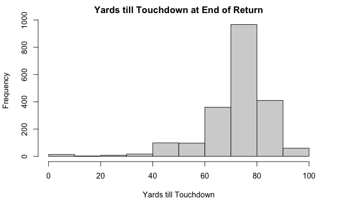

```r
YardsTillTouchdownHist <- hist(final.data.returns$yardsTillTouchdown, main = "Yards till Touchdown at End of Return", xlab = "Yards till Touchdown")
```

```r
YardsTillTouchdownHist
```

```
$breaks
 [1]   0  10  20  30  40  50  60  70  80  90 100

$counts
 [1]  14   3   8  17  99  97 360 967 410  60

$density
 [1] 0.0006879607 0.0001474201 0.0003931204 0.0008353808 0.0048648649 0.0047665848 0.0176904177 0.0475184275 0.0201474201 0.0029484029

$mids
 [1]  5 15 25 35 45 55 65 75 85 95

$xname
[1] "final.data.returns$yardsTillTouchdown"

$equidist
[1] TRUE

attr(,"class")
[1] "histogram"
```

Create boxplot of target variable.

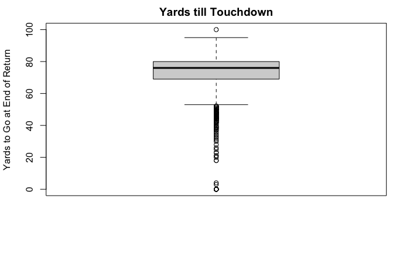

```r
yardsTillTouchdownBoxplot <- boxplot(final.data.returns$yardsTillTouchdown, data=final.data.returns, main="Yards till Touchdown", ylab="Yards to Go at End of Return")
```

Export data frames to CSV.

```r
write.csv(final.data.returns,"~/Documents/2022bdb/final.data.returns.csv", row.names = FALSE)
write.csv(final.data.touchbacks,"~/Documents/2022bdb/final.data.touchbacks.csv", row.names = FALSE)
```